# Codebook for final

## gender_2016

| Feature | Result |
| --- | --- |
| Variable type | factor |
| Number of missing obs. | 0 (0 %) |
| Number of unique values | 2 |
| Mode | “F” |
| Reference category | F |

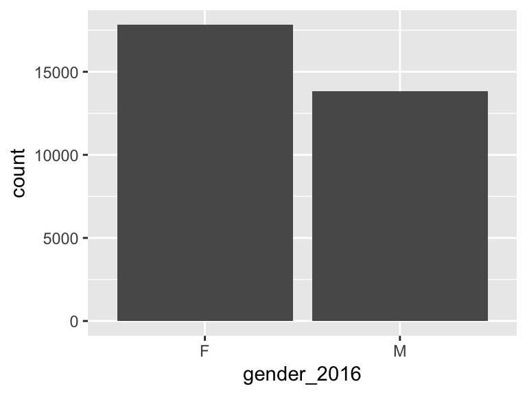

- Observed factor levels: "F", "M".

## num_children_2016

| Feature | Result |
| --- | --- |
| Variable type | integer |
| Number of missing obs. | 0 (0 %) |
| Number of unique values | 1385 |
| Median | 16 |
| 1st and 3rd quartiles | 8; 45 |
| Min. and max. | 5; 19414 |

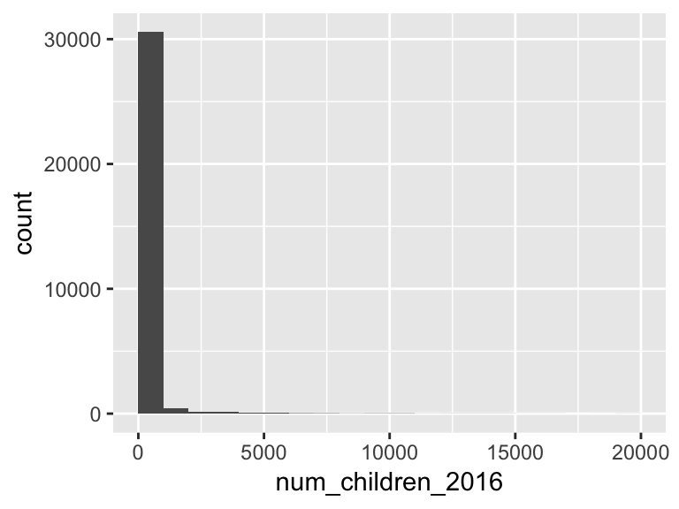

## gender_2015

| Feature | Result |
| --- | --- |
| Variable type | factor |
| Number of missing obs. | 0 (0 %) |
| Number of unique values | 2 |
| Mode | “F” |
| Reference category | F |

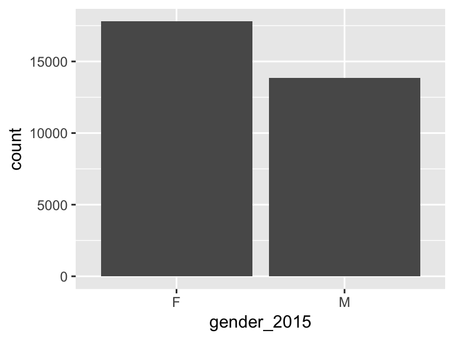

- Observed factor levels: "F", "M".

## num_children_2015

| Feature | Result |
| --- | --- |
| Variable type | integer |
| Number of missing obs. | 0 (0 %) |
| Number of unique values | 1397 |
| Median | 16 |
| 1st and 3rd quartiles | 8; 46 |
| Min. and max. | 5; 20415 |

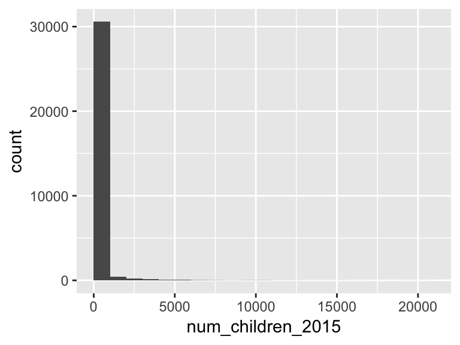

## total

| Feature | Result |
| --- | --- |
| Variable type | integer |
| Number of missing obs. | 0 (0 %) |
| Number of unique values | 2558 |
| Median | 35 |
| 1st and 3rd quartiles | 18; 104 |
| Min. and max. | 10; 39829 |

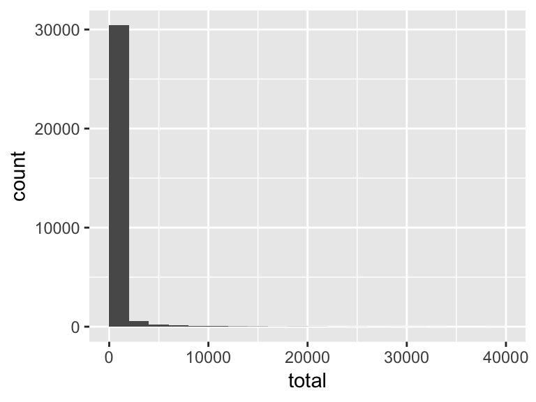

Report generation information:

- Created by Pankaj Kumar (username: `pankaj`).
- Report creation time: Tue Dec 11 2018 07:31:08
- Report was run from directory: `/Users/pankaj/Dropbox/SMU _DS_HomeWork/Doind_DS_term1/UNIT5_2_2`
- dataMaid v1.2.0 [Pkg: 2018-10-03 from CRAN (R 3.5.0)]
- R version 3.5.1 (2018-07-02).
- Platform: x86_64-apple-darwin15.6.0 (64-bit)(macOS High Sierra 10.13.6).
- Function call: `makeDataReport(data = final, mode = c("summarize", "visualize", "check"), smartNum = FALSE, file = "codebook_final.Rmd", checks = list( character = "showAllFactorLevels", factor = "showAllFactorLevels", labelled = "showAllFactorLevels", haven_labelled = "showAllFactorLevels", numeric = NULL, integer = NULL, logical = NULL, Date = NULL), listChecks = FALSE, maxProbVals = Inf, codebook = TRUE, reportTitle = "Codebook for final")`